# Finding correlations in the newStarwars dataset

Kirsty Kitto

This is an attempt by me to learn how to use it.

Kirsty is having fun

Lets go get us a dataset!

`r`r library(tidyverse) starwars

| name | height | mass | hair_color | skin_color | eye_color | birth_year | gender | homeworld | species | films | vehicles | starships |
| --- | --- | --- | --- | --- | --- | --- | --- | --- | --- | --- | --- | --- |
| Luke Skywalker | 172 | 77.0 | blond | fair | blue | 19.0 | male | Tatooine | Human |  |  |  |
| C-3PO | 167 | 75.0 | NA | gold | yellow | 112.0 | NA | Tatooine | Droid |  |  |  |
| R2-D2 | 96 | 32.0 | NA | white, blue | red | 33.0 | NA | Naboo | Droid |  |  |  |
| Darth Vader | 202 | 136.0 | none | white | yellow | 41.9 | male | Tatooine | Human |  |  |  |
| Leia Organa | 150 | 49.0 | brown | light | brown | 19.0 | female | Alderaan | Human |  |  |  |
| Owen Lars | 178 | 120.0 | brown, grey | light | blue | 52.0 | male | Tatooine | Human |  |  |  |
| Beru Whitesun lars | 165 | 75.0 | brown | light | blue | 47.0 | female | Tatooine | Human |  |  |  |
| R5-D4 | 97 | 32.0 | NA | white, red | red | NA | NA | Tatooine | Droid |  |  |  |
| Biggs Darklighter | 183 | 84.0 | black | light | brown | 24.0 | male | Tatooine | Human |  |  |  |
| Obi-Wan Kenobi | 182 | 77.0 | auburn, white | fair | blue-gray | 57.0 | male | Stewjon | Human |  |  |  |

[output cut: 77 more lines]

Let’s add a calculation for BMI

`r`r starwars %>% mutate(BMI:=mass/((height/100)^2)) -> newStarwars ggplot(data = newStarwars, mapping = aes(x = mass, y = BMI)) + geom_point()

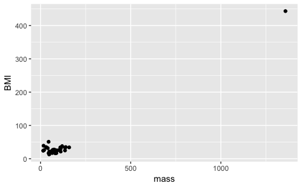

Hmmm… should probably remove the outlier

`r`r newStarwars %>% filter((BMI<400)) -> newStarwars ggplot(data = newStarwars, mapping = aes(x = mass, y = BMI)) + geom_point()

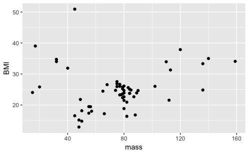

Hmmmm. Looks not terribly informative… what about BMI vs height?

`r`r ggplot(data = newStarwars, mapping = aes(x = height, y = BMI)) + geom_point()

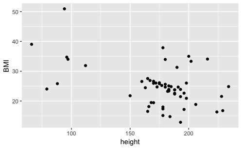

# Right… your challenge is to work out if there is a correlation between BMI and height! (And to show evidence of why you think there is/is not using R!)

# Instructions

The repo that you have pulled includes:

1. A README file
2. This .Rmd file
3. A dataset (the newStarwars dataset)

Each group (around a table) will modify the first two of these files during this activity. (Remember to leave a commit message so we know what you are changing!)

Your group modifications should add a code chunk to this document that

1. Updates the group number title below with a heading that explains your approach towards finding correlations
2. Adds some standard text to explain how you are finding correlation in the newStarwars dataset
3. Includes a statistical analysis using a R function to explore whether there is a correlation between BMI and height

# Group 1

# Group 2

# Group 3

# Group 4

# Group 5

# Group 6

# Group 7

# Group 8

# Group 9

# Group 10